# Lab 9: Modeling Data 2

Analysis of Environmental Data

Elyse McCormick

2022-11-09

**Q1 (1 pt.): State the null hypothesis of the Chi-square test.Make sure you state the null hypothesis in terms of Brown Creeper presence/absence and edge/interior habitats.**

The null hypothesis for this analysis states that brown creepers show no difference in presence between what we observe and what we expect between forest interiors versus forest edges.

**Q2 (2 pts.): Consider the results of your test and explain whether you think that Brown Creepers show a significant habitat preference.Make sure your use the output of your statistical test to support your answer.**

```
## here() starts at C:/Users/elyse/Documents/University of Massachusetts/ECO_602/environmental_data
```

```
##
##                 Presence Absence
##   Forest Edge         29     144
##   Inside Forest      314     559
```

```
##
##  Pearson's Chi-squared test with Yates' continuity correction
##
## data:  br_creeper_table
## X-squared = 23.3, df = 1, p-value = 1.386e-06
```

**Q3 (1 pt.): Show the R-code you can use to create a model fit (call it fit_species) of penguin body mass as predicted by penguin species.**

```r
require(palmerpenguins)
fit_species =
  lm(
    formula = body_mass_g ~ species,
    data = penguins)
```

**Q4 (1 pt.): Show the R-code you can use to create a model fit (call it fit_sex) of penguin body mass as predicted by sex.**

```r
fit_sex =
  lm(
    formula = body_mass_g ~ sex,
    data = penguins)
```

**Q5 (1 pt.): Show the R-code you can use to create a model fit (call it fit_both) of penguin body mass as predicted by species and sex. This should be an interactive model, i.e. it should include a sex:species interaction.**

```r
Fit_both =
  lm(
    formula = body_mass_g ~ species * sex,
    data = penguins)
```

**Q6 (1 pt.): Include a conditional boxplot corresponding to the grouping structure in your fit_species model.**

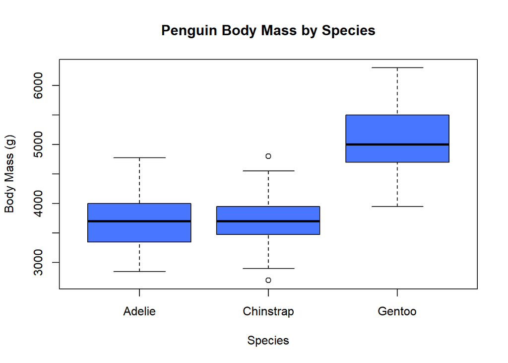

```r
boxplot(formula = body_mass_g ~ species, data = penguins, main = "Penguin Body Mass by Species",
        xlab = "Species", ylab = "Body Mass (g)", col = "royalblue1")
```

**Q7 (1 pt.): Include a conditional boxplot corresponding to the grouping structure in your fit_sex model.**

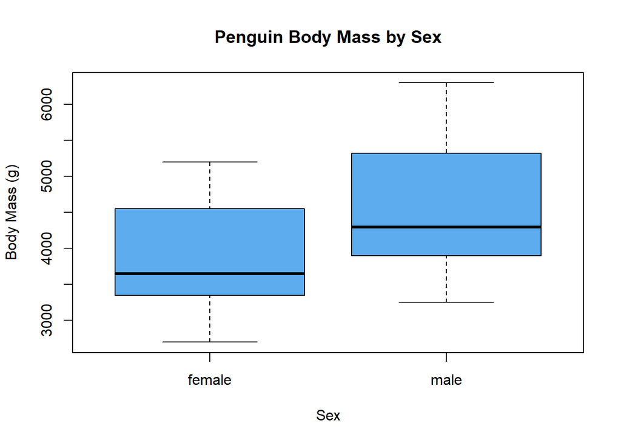

```r
boxplot(formula = body_mass_g ~ sex, data = penguins, main = "Penguin Body Mass by Sex",
        xlab = "Sex", ylab = "Body Mass (g)", col = "steelblue2")
```

**Q8 (3 pts.): Include a conditional boxplot corresponding to the grouping structure in your fit_both model.Your group labels must all correspond to the correct box, be visible, and sensible.**

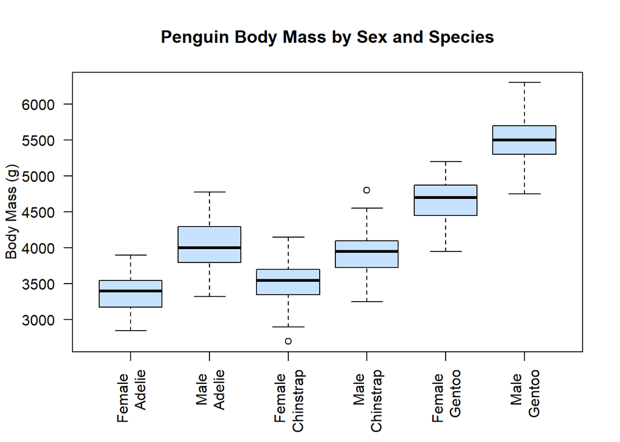

```r
boxplot(formula = body_mass_g ~ sex * species, data = penguins,
        main = "Penguin Body Mass by Sex and Species",
        names = c(" Female \n Adelie", "Male \n Adelie", "Female \n Chinstrap", "Male \n Chinstrap",
                  "Female \n Gentoo", "Male \n Gentoo"),
        xlab = "",
        ylab = "Body Mass (g)", las = 2, col = "slategray1")
```

**Q9 (3 pts.): Based on the shapes of the boxes, which of the models (if any) do you think may have problems fulfilling the homogeneity assumption?**

Based on the shape of these boxes, I don’t think any of these models have issues fulfilling the homogeneity of variance. Eeach model appears to have a roughly equal spread of the data, and while the fit by sex doesn’t have a central median, the overall spread and shape of the boxes, which are more indicative of the variance, are relatively similar.

**Q10 (1 pt.): State the null hypothesis of the Bartlett test.**

The Bartlett test’s null hypothesis is that there is no difference in variance between body mass for sex and species.

**Q11 (1 pt.): What was the p-value from the Bartlett test of homogeneity for observations grouped by species? You can round your answer to 4 decimal digits.**

```r
bartlett.test(body_mass_g ~ species, data = penguins)
```

```
##
##  Bartlett test of homogeneity of variances
##
## data:  body_mass_g by species
## Bartlett's K-squared = 5.9895, df = 2, p-value = 0.05005
```

**Q12 (1 pt.): What was the p-value from the Bartlett test of homogeneity for observations grouped by sex? You can round your answer to 4 decimal digits.**

```r
bartlett.test(body_mass_g ~ sex, data = penguins)
```

```
##
##  Bartlett test of homogeneity of variances
##
## data:  body_mass_g by sex
## Bartlett's K-squared = 4.6017, df = 1, p-value = 0.03194
```

**Q13 (1 pt.): What was the p-value from the Bartlett test of homogeneity for observations grouped by both factors? You can round your answer to 4 decimal digits.**

```r
dat_groups = aggregate(
  formula = body_mass_g ~ species * sex,
  data = penguins,
  FUN = c)
str(dat_groups)
```

```
## 'data.frame':    6 obs. of  3 variables:
##  $ species    : Factor w/ 3 levels "Adelie","Chinstrap",..: 1 2 3 1 2 3
##  $ sex        : Factor w/ 2 levels "female","male": 1 1 1 2 2 2
##  $ body_mass_g:List of 6
##   ..$ : int  3800 3250 3450 3625 3200 3700 3450 3325 3400 3800 ...
##   ..$ : int  3500 3525 3950 3250 4150 3800 3700 3575 3700 3450 ...
##   ..$ : int  4500 4450 4550 4800 4400 4650 4650 4200 4150 4800 ...
##   ..$ : int  3750 3650 4675 3800 4400 4500 4200 3600 3950 3800 ...
##   ..$ : int  3900 3650 3725 3750 3700 3775 4050 4050 3300 4400 ...
##   ..$ : int  5700 5700 5400 5200 5150 5550 5850 5850 6300 5350 ...
```

```r
dat_groups$body_mass_g
```

```
## [[1]]
##  [1] 3800 3250 3450 3625 3200 3700 3450 3325 3400 3800 3800 3200 3150 3250 3300
## [16] 3325 3550 3300 3150 3100 3000 3450 3500 3450 2900 3550 2850 3150 3600 2850
## [31] 3350 3050 3600 3550 3700 3700 3550 3200 3800 3350 3500 3600 3550 3400 3300
## [46] 3700 2900 3725 3075 2925 3750 3175 3825 3200 3900 2900 3350 3150 3450 3050
## [61] 3275 3050 3325 3500 3425 3175 3400 3400 3050 3000 3475 3450 3700
##
## [[2]]
##  [1] 3500 3525 3950 3250 4150 3800 3700 3575 3700 3450 3600 2900 3300 3400 3700
## [16] 3200 3350 3900 3850 2700 3650 3500 3675 3400 3675 3325 3600 3350 3250 3525
## [31] 3650 3650 3400 3775
##
## [[3]]
##  [1] 4500 4450 4550 4800 4400 4650 4650 4200 4150 4800 5000 4400 5000 4600 4700
## [16] 5050 5150 4950 4350 3950 4300 4900 4200 5100 4850 4400 4900 4300 4450 4200
## [31] 4400 4700 4700 4750 5200 4700 4600 4750 4625 4725 4750 4600 4875 4950 4750
## [46] 4850 4875 4625 4850 4975 4700 4575 5000 4650 4375 4925 4850 5200
##
## [[4]]
##  [1] 3750 3650 4675 3800 4400 4500 4200 3600 3950 3800 3550 3950 3900 3900 4150
## [16] 3950 4650 3900 4400 4600 3425 4150 4300 4050 3700 3800 3750 4400 4050 3950
## [31] 4100 4450 3900 4150 4250 3900 4000 4700 4200 3550 3800 3950 4300 4450 4300
## [46] 4350 4100 4725 4250 3550 3900 4775 4600 4275 4075 3775 3325 3500 3875 4000
## [61] 4300 4000 3500 4475 3900 3975 4250 3475 3725 3650 4250 3750 4000
##
## [[5]]
##  [1] 3900 3650 3725 3750 3700 3775 4050 4050 3300 4400 3400 3800 4150 3800 4550
## [16] 4300 4100 3600 4800 4500 3950 3550 4450 4300 3250 3950 4050 3450 4050 3800
## [31] 3950 4000 3775 4100
##
## [[6]]
##  [1] 5700 5700 5400 5200 5150 5550 5850 5850 6300 5350 5700 5050 5100 5650 5550
## [16] 5250 6050 5400 5250 5350 5700 4750 5550 5400 5300 5300 5000 5050 5000 5550
## [31] 5300 5650 5700 5800 5550 5000 5100 5800 6000 5950 5450 5350 5600 5300 5550
## [46] 5400 5650 5200 4925 5250 5600 5500 5500 5500 5500 5950 5500 5850 6000 5750
## [61] 5400
```

```r
bartlett.test(dat_groups$body_mass_g)
```

```
##
##  Bartlett test of homogeneity of variances
##
## data:  dat_groups$body_mass_g
## Bartlett's K-squared = 7.6908, df = 5, p-value = 0.1741
```

**Q14 (3 pts.): Based on the results of the Bartlett tests, do you anticipate any issues with heterogeneity in any of the models? Make sure you justify your response with the results of your tests.**

**Q15 (5 pts.): Perform a graphical exploration of the dataset. Create the following plots and include them in your report. You may create separate figures, or combine them into one multi-panel figure.** **A barplot of counts of trees in each probability of failure class (column ProbabilityofFailure)** **A barplot of the counts of trees in each of the failure classes (column Failure_Standardized)** **A histogram of DBH** **A scatterplot of DBH (x-axis) and tree height (y axis)**

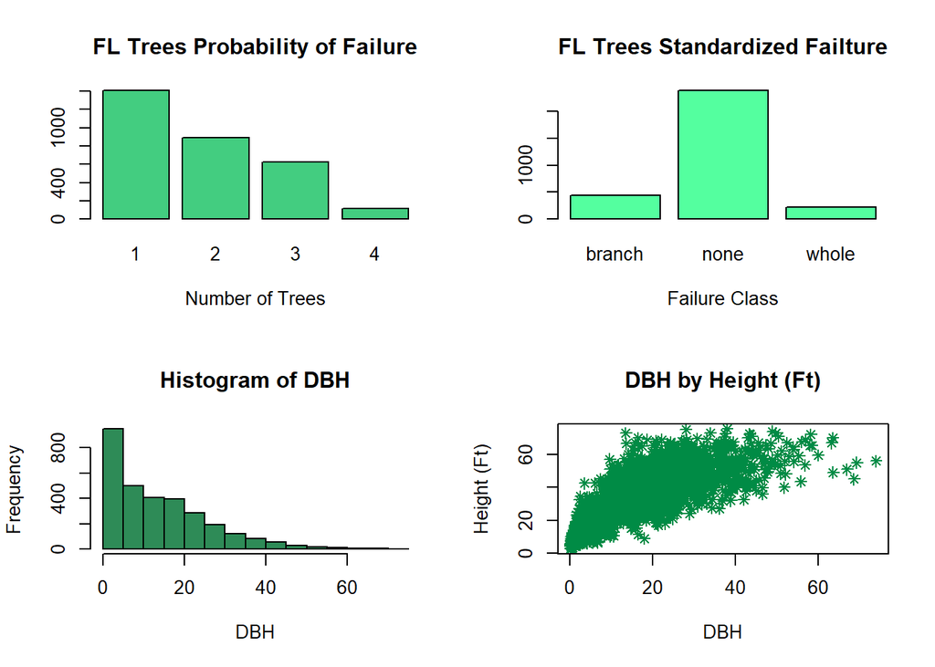

```r
require(here)
FL_trees <- read.csv(here("data", "trees_FL.csv"))

fail <- table(FL_trees$ProbabilityofFailure)
stfail <- table(FL_trees$Failure_Standardized)
par(mfrow = c(2,2))
barplot(fail, main = "FL Trees Probability of Failure", xlab = "Number of Trees",
        col = "seagreen3")
barplot(stfail, main = "FL Trees Standardized Failture", xlab = "Failure Class",
        col = "seagreen1")
hist(FL_trees$DBH_in, main = "Histogram of DBH", xlab = "DBH", col = "seagreen")
plot(FL_trees$DBH, FL_trees$HeighttoTop_ft, main = "DBH by Height (Ft)", xlab = "DBH", ylab = "Height (Ft)",
     col = "springgreen4", pch = 8)
```

**Q16 (1 pt.): State the null hypothesis for the Kolmogorov-Smirnov test. Your answer should be in terms of the DBH of the two groups of trees.**

**Q17 (1 pt.): What was the p-value of the test? Based on the evidence, do you think the distribution of DBH is the same for the two groups?**

```r
FL_treesn <- droplevels(subset(FL_trees, Failure_Standardized == "none"))
FL_treesb <- droplevels(subset(FL_trees, Failure_Standardized == "branch"))
FL_treesw <- droplevels(subset(FL_trees, Failure_Standardized == "whole"))

ks.test(FL_treesn$DBH_in, FL_treesw$DBH_in)
```

```
##
##  Two-sample Kolmogorov-Smirnov test
##
## data:  FL_treesn$DBH_in and FL_treesw$DBH_in
## D = 0.10643, p-value = 0.02125
## alternative hypothesis: two-sided
```

**Q18 (1 pt.): Qualitatively describe the shape of the relationship betwen DBH and height. Is it linear? Curved? Monotonic?**

The relationship between DBH and height looks roughly linear and monotonic, but it may have a slight curve at the base. Since it potentially has this curve, it’s possibly non-parametric. relationship.

**Q19 (1 pt.): Given your answer to the previous question, which type of correlation coefficient is most appropriate?**

The most appropriate correlation coefficient in Spearman’s correlation coefficient.

**Q20 (1 pt.): What is the p-value? Do you conclude that the two variables are significantly correlated?**

```r
cor.test(FL_trees$DBH,
         FL_trees$HeighttoTop_ft,
         use='complete.obs',
         method = "spearman")
```

```
##
##  Spearman's rank correlation rho
##
## data:  FL_trees$DBH and FL_trees$HeighttoTop_ft
## S = 541454081, p-value < 2.2e-16
## alternative hypothesis: true rho is not equal to 0
## sample estimates:
##       rho
## 0.8850462
```

Based on the p-value from the Spearman’s correlation test, there is a significant correlation between DBH and tree height (p < 2.2e-16).

**Q21 (2 pts.): What was the value of the test statistic (X-squared)? What was the corresponding p-value?**

[output not shown]

```
Pearson's Chi-squared test
```

data: fl_table_2 X-squared = 202.65, df = 3, p-value < 2.2e-16

**Q22 (1 pt.): What is the value of the chi-square residual (rounded to the nearest whole number) for the count of failures in probability category 1?**

**Q23 (1 pt.): Were there more, or fewer, tree failures than expected by chance in failure probability category #1?**

**Q24 (1 pt.): Were there more, or fewer, tree failures than expected by chance in failure probability category #4?**

**Q25 (2 pts.): Given your answers to the previous two questions, do you conclude that the probability of failure rating system is effective?**